# Graphical analysis of motion

# Equations of one dimentional motion

Instanteanous speed is defined by the specific displacement in a speccific time time ratio like as:

\begin{equation} v = \dfrac{\Delta x}{\Delta t} = \dfrac{x_2-x_1}{t_2-t_1} \end{equation}

so, the change of velocity as a function of time define acceleration (instantanoeus) , then : \begin{equation} a = \dfrac{\Delta v}{\Delta t} = \dfrac{v_2-v_1}{t_2-t_1} \end{equation}

# Example

We have a car toy and a rule , the toy position along of rule at different time shows in the table.

| Time (s) | Position (cm) |
| --- | --- |
| 0 | 0 |
| 5 | 4.1 |
| 10 | 7.9 |
| 15 | 12.1 |
| 20 | 16.0 |
| 25 | 16.0 |
| 30 | 16.0 |
| 35 | 18.0 |
| 40 | 20.1 |
| 45 | 21.9 |
| 50 | 24.0 |
| 55 | 22.1 |
| 60 | 20.0 |

## Pyhton code

We first must be to call necessary packages

```python
import numpy as np
import scipy as sp
import matplotlib.pyplot as plt
import matplotlib as mpl
from IPython.display import display, Math, Latex

# Plots parameters
mpl.rcParams['figure.dpi']= 180
plt.style.use('science')
plt.rcParams.update({
       "font.size":10})
```

### Plot Distance vs Time

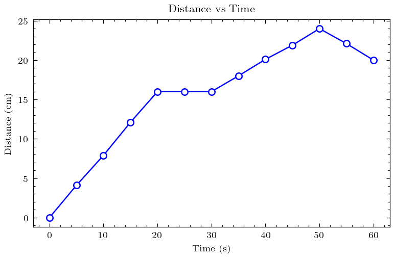

```python
# We create timne and  position lists
time = np.arange(0,65,5)
position = np.array([0,4.1,7.9,12.1,16.0,16.0,16.0,18.0,20.1,21.9,24.0,22.1,20.0])

plt.figure(figsize=(5,3))
plt.plot(time,position,'o-b',mfc='white',ms=5)
plt.xlabel('Time (s)')
plt.ylabel('Distance (cm)')
plt.title('Distance vs Time')
plt.show()
```

### Compute instantanous speed

From eq.(1) we can compute the instantanoeus speed in each instant of time, then : \begin{equation} v_{1\to 2} = \dfrac{x_2-x_1}{t_2-t_1} = \dfrac{4.1-0}{5-0} = 0.82 \text{cm/s} \end{equation}

```python
x2=4.1;x1=0
t2=5;t1=0

v12 = (x2-x1)/(t2-t1)
print('v = %f'%v12)
```

```
v = 0.820000
```

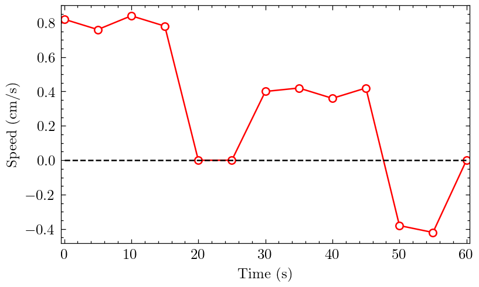

```python
v =np.zeros((len(time),2))
for i in range(1,len(time)):
    deltat = time[i]-time[i-1]
    deltax = position[i]-position[i-1]
    velocity = deltax/deltat
    v[i-1,1]=velocity
    v[i,0]=time[i]
plt.figure(figsize=(5,3))
plt.plot(v[:,0],v[:,1],'o-r',mfc='white',ms=5)
plt.plot([0,60],[0,0],'--k',lw=1)
plt.xlabel('Time (s)')
plt.ylabel('Speed (cm/s)')
plt.xlim([-.5,60.5])

plt.show()
```

### Compute instantanous acceleration

```python
v2=v[1,1];v1=v[0,1]
t2=time[1];t1=time[0]

a12 = (v2-v1)/(t2-t1)
print('a = %f'%a12)
```

```
a = -0.012000
```

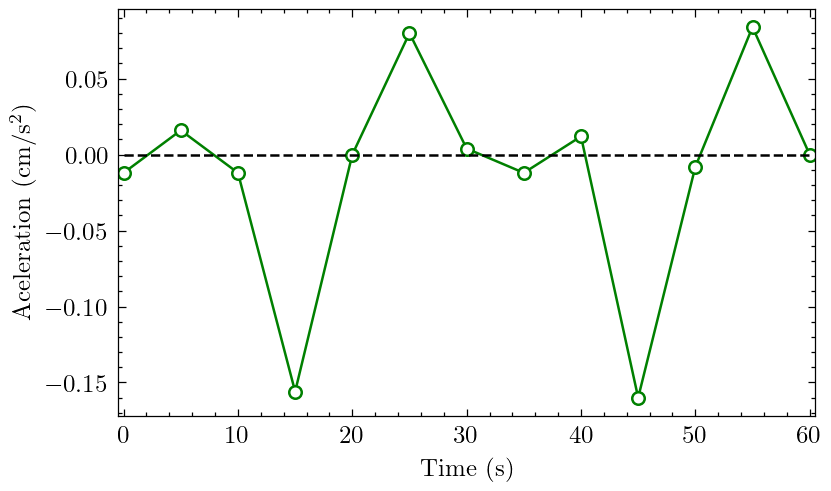

```python
a =np.zeros((len(time),2)) # aceleration 1D array
for i in range(1,len(time)):
    deltat = time[i]-time[i-1]
    deltav = v[i,1]-v[i-1,1]
    aceleration = deltav/deltat
    a[i-1,1]=aceleration
    a[i,0]=time[i]

# graphics
plt.figure(figsize=(5,3))
plt.plot(a[:,0],a[:,1],'o-g',mfc='white',ms=5)
plt.plot([0,60],[0,0],'--k',lw=1)
plt.xlabel('Time (s)')
plt.ylabel('Aceleration (cm/s$^2$)')
plt.xlim([-0.5,60.5])
plt.show()
```

# Comparative of three plots

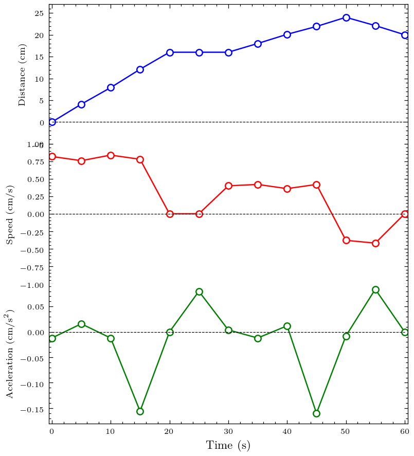

```python
plt.rcParams['font.size']= 6
fig, [ax1,ax2,ax3]= plt.subplots(3, 1, sharex=True,figsize=(5,6))
fig.subplots_adjust(hspace=0)
ax1.spines['bottom'].set_visible(False)
ax2.spines['bottom'].set_visible(False)
ax2.spines['top'].set_visible(False)
ax1.tick_params(axis='x', which='both',bottom=False)
ax2.tick_params(axis='x', which='both',top=False)
ax3.spines['top'].set_visible(False)
ax2.tick_params(axis='x', which='both',bottom=False)
ax3.tick_params(axis='x', which='both',top=False)

ax1.plot(time,position,'o-b',mfc='white',ms=5)
ax1.set_ylim([-5,27])
ax1.plot([0,60],[0,0],'--k',lw=0.5)
ax1.set_ylabel('Distance (cm)',fontsize=7)

ax2.plot(v[:,0],v[:,1],'o-r',mfc='white',ms=5)
ax2.plot([0,60],[0,0],'--k',lw=0.5)
ax2.set_ylabel('Speed (cm/s)',fontsize=7)
ax2.set_ylim([-1,1])


ax3.plot(a[:,0],a[:,1],'o-g',mfc='white',ms=5)
ax3.set_xlim([-.5,60.5])
ax3.plot([0,60],[0,0],'--k',lw=0.5)
ax3.set_xlabel('Time (s)',fontsize=9)
ax3.set_ylabel('Aceleration (cm/s$^2$)',fontsize=7)
ax3.set_ylim([-0.18,0.095])

plt.show()
```

# References

[1] Serway, R. A., & Jewett, J. W. (2018). Physics for scientists and engineers. Cengage learning.